# ラスターデータによる標高図の可視化

静岡県，伊豆地域，横浜市の例

[岩田真一郎](https://shinichiro-iwata.github.io/)（ [神奈川大学経済学部](https://www.econ.kanagawa-u.ac.jp/)）

2024-04-28作成，2025-03-11改定

# 1 目的

- [Hillshade effects](https://dominicroye.github.io/en/2022/hillshade-effects/)（アクセス日：2024-04-26）を参考に光源の位置と方向を活用して，地形の陰影を生成し，山や谷の輪郭を浮かび上がらせる（**陰影起伏図**）．
- 標高図と陰影起伏図を組み合わせ，色付き陰影起伏図（**陰影段彩図**）を作成する．
  - **ラスターデータ**：セル（格子状の区画）で地理空間情報を表現するデータ形式．[^1]

```r
library(tidyverse)
#地図（静岡県）ダウンロード
library(rnaturalearth)
#標高データダウンロード
library(elevatr)
#標高データ操作
library(terra)
#スケールの複数使用
library(ggnewscale)
#地図（伊豆地域，横浜市）の読込
library(sf)
```

# 2 標高図の作成

## 2.1 標高データのダウンロード

- 標高を示す地域として静岡県を選定．[Natural Earth](https://www.naturalearthdata.com/)に収録されている静岡県ポリゴンを`ne_states()`で読込．[^2]
  - 静岡県は日本の都道府県のため国は`Japan`を指定．
  - `sf`クラスを指定．
  - オブジェクトを`Japan_map`とする．

```r
Japan_map <-
  ne_states("Japan", returnclass="sf")

Shizuoka <- Japan_map %>%
  filter(name=="Shizuoka")
```

- `get_elev_raster()`：指定した位置の標高データ（ラスターデータ）をダウンロード.`AWS Terrain Tiles`から標高データを取得`
  - `locations`：位置情報を指定．今回は静岡県（`Shizuoka`）
  - `z`：解像度（ズームレベル）の指定．数を大きくすると解像度が増すが，時間がかかるため**注意**．
  - `clip`： `locations`を設定した場合，指定した位置のデータを切り取る（`bbox`を設定した場合，境界ボックスに合わせてデータを切り取る）．

```r
elev <-
  get_elev_raster(locations=Shizuoka,
                  z=9, clip="locations")
```

- `ggplot()`で可視するため，`elev`をデータフレーム（`as.data.frame()`）に変更．
  - `xy=TRUE`を指定することで，座標情報をデータフレームの列として取り込む．

```r
elev_df <- elev %>%
  as.data.frame(xy=TRUE)
```

## 2.2 データ処理

- `elev_df`の3列目が標高を示すため，列名を`elvation`に変更．
- データフレームの欠損値（`NA`）削除（`drop_na(everything())`）．

```r
elev_df <- elev_df %>%
  rename("elevation"=3)

elev_df <- elev_df %>%
  drop_na(everything())
```

## 2.3 標高図

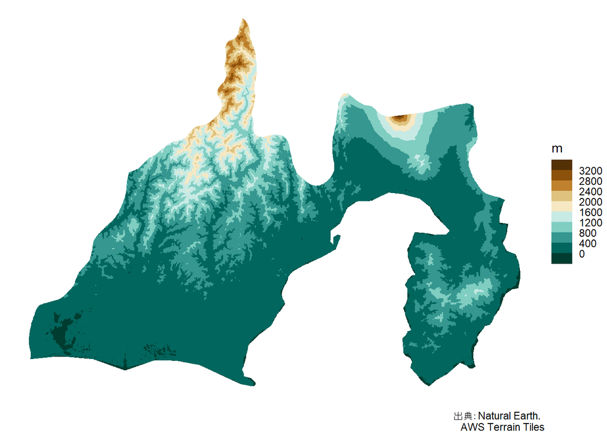

```r
#凡例目盛り
my_breaks <- seq(0, 3200, by=400)

ggplot() +
  geom_raster(data=elev_df,
              aes(x, y, fill=elevation))+
  scale_fill_fermenter(palette="BrBG",
                       breaks=my_breaks)+
  labs(fill="m",
       caption="出典：Natural Earth，
       AWS Terrain Tiles")+
  coord_sf(crs="EPSG:6668")+
  theme_void()
```

# 3 陰影起伏図の作成

## 3.1 陰影計算

- `terrain()`：標高データ（`elv`）から地形特性を計算する関数．
  - 傾斜（`slope`）をラジアン単位（`radians`）で計算するように指示．
  - 斜面方位（`aspect`）をラジアン単位（`radians`）で計算するように指示．

```r
sl <- elev %>%
  terrain("slope", unit="radians")

asp <- elev %>%
  terrain("aspect", unit="radians")
```

- `shade()`：陰影計算．
  - `angle`：光源高度`45`度に指示．
  - `direction`：光源方向`315`度に指示．

**注意**：このまま`shade()`を指示すると，

```
inherits(slope, "SpatRaster") は TRUEではありません
```

と出るため`raster`を`SpatRaster`オブジェクトに変更．

```r
sl <- sl %>%
  as("SpatRaster")
asp <- asp %>%
  as("SpatRaster")

hill_shade <-
  shade(sl, asp,
      angle=45,
      direction=315,
      normalize=TRUE)
```

- `hill_shade`もデータフレーム（`as.data.frame()`）に変更．

```r
hill_shade_df <- hill_shade %>%
  as.data.frame(xy=TRUE)
```

## 3.2 陰影起伏図

- 陰影起伏（`hill_shade_df`の`hillshade`列）を紫色（`Purples`）で表現．
  - `show.legend=FALSE`：凡例非表示．

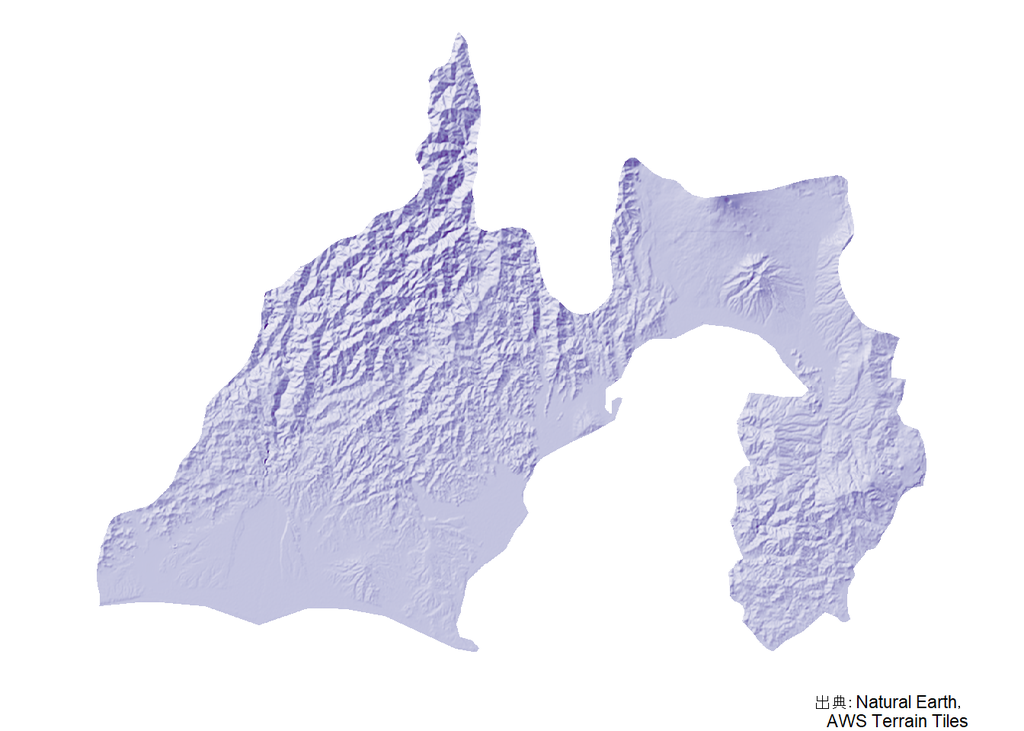

```r
ggplot() +
  geom_raster(data=hill_shade_df,
              aes(x, y, fill=hillshade),
              show.legend=FALSE)+
  scale_fill_distiller(palette="Purples")+
  labs(caption="出典：Natural Earth，
       AWS Terrain Tiles")+
  coord_sf(crs="EPSG:6668")+
  theme_void()
```

# 4 陰影段彩図

- 標高図と陰影起伏図を組み合わせ，色付き陰影起伏図（「陰影段彩図」）を作成．
- 地図の順番．
  - 最下層：陰影起伏図（`hill_shade_df`）．
  - `new_scale_fill()`：重ねる標高地図の色付けを活かすため．
  - 最上層：標高図（`elev_df`）．`alpha`を利用して透過表示．

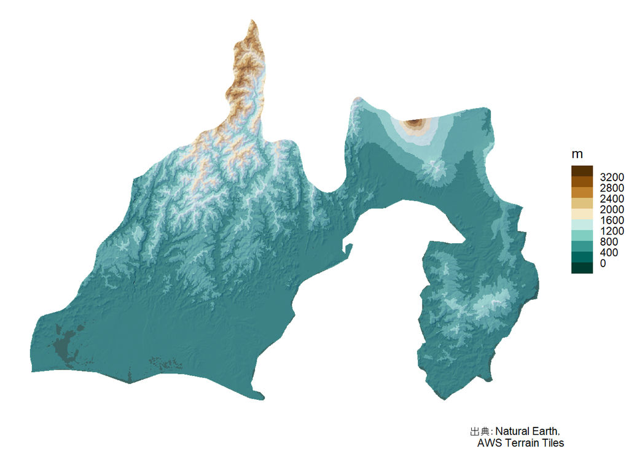

```r
ggplot() +
  geom_raster(data=hill_shade_df,
              aes(x, y, fill=hillshade),
              show.legend=FALSE)+
  scale_fill_distiller(palette="Purples")+
  new_scale_fill() +
  geom_raster(data=elev_df,
              aes(x, y, fill=elevation),
              alpha=0.7) +
  scale_fill_fermenter(palette="BrBG",
                       breaks=my_breaks)+
  labs(fill="m",
       caption="出典：Natural Earth，
       AWS Terrain Tiles") +
  coord_sf(crs="EPSG:6668") +
  theme_void()
```

# 5 応用（等高線の追加）

- 同じ標高を線で表すことで**[等高線](https://ja.wikipedia.org/wiki/%E7%AD%89%E9%AB%98%E7%B7%9A)**を作成．

## 5.1 伊豆地域

**上の静岡県との違い**

1. [Natural Earth](https://www.naturalearthdata.com/)から伊豆半島のポリゴンを正確に切り抜くのが難しいこと．
- これに対しては，[国土数値情報ダウンロードサイト](https://nlftp.mlit.go.jp/ksj/)の[行政区域データ](https://nlftp.mlit.go.jp/ksj/gml/datalist/KsjTmplt-N03-2024.html)を活用することにより対応．[伊豆地域](https://b-izu.com/about/)ポリゴンの作成方法は[標高・傾斜度メッシュデータの可視化](https://shinichiro-iwata.github.io/geospatial-data-visualization/elevation-slope-visualization.html)を参照．
2. 伊豆地域のポリゴンを`Izu`と名付ける．
- `z`：解像度を`8`に指定して，標高データ（ラスターデータ）をダウンロード.
- 後は原則，静岡県のケースと同じであるため`R`コードは省略．

```r
Izu_elev <-
  get_elev_raster(locations=Izu,
                  z=8, clip="locations")
```

## 5.2 伊豆地域の陰影段彩図

3. 陰影起伏図（データフレーム）のオブジェクトを`hillshade_Izu_df`とする．静岡県同様に標高図（オブジェクトを`Izu_elev_df`とする）と組み合わせ陰影段彩図を作成しようとしたところ，`geom_raster()`ではなく`geom_tile()`を勧められたため，変更．

**等高線の作成**

- `geom_contour()`：等高線の作成．2変数（`x`軸と`y`軸）に対する`z`軸の値を表現．ここで等高線の高さ．内側がより高い値．
  - 線の色（`color`）と太さ（`linewidth`）の指定．

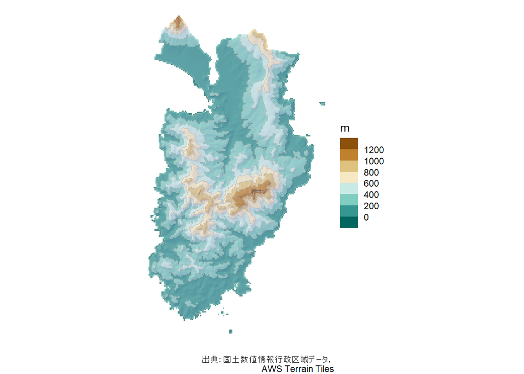

```r
#凡例目盛り
my_breaks <- seq(0, 1200, by=200)

ggplot() +
  geom_tile(data=hillshade_Izu_df,
              aes(x, y, fill=hillshade),
              show.legend=FALSE)+
  scale_fill_distiller(palette="Purples")+
  new_scale_fill() +
  geom_tile(data=Izu_elev_df,
              aes(x, y, fill=elevation),
              alpha=0.7)+
  scale_fill_fermenter(palette="BrBG",
                       breaks=my_breaks)+
  geom_contour(data=Izu_elev_df,
               aes(x, y, z=elevation),
               color="gray70", linewidth=0.2)+
  labs(fill="m",
       caption="出典：国土数値情報行政区域データ，
       AWS Terrain Tiles") +
  coord_sf(crs="EPSG:6668") +
  theme_void()
```

# 6 横浜市

- [国土数値情報行政区域データ](https://nlftp.mlit.go.jp/ksj/gml/datalist/KsjTmplt-N03-2024.html)から神奈川県をダウンロード．
  - 横浜市を選抜．

```r
Kanagawa_map<-
  read_sf("N03-20240101_14_GML/N03-20240101_14.shp")

Kanagawa_map %>%
  filter(N03_004=="横浜市") ->
  Yokohama
```

- 標高データのダウンロード．解像度を`10`に指定．
- 後は原則，静岡県のケースと同じであるため`R`コードは省略．

```r
Yokohama_elev <-
  get_elev_raster(locations=Yokohama,
                  z=10, clip="locations")
```

## 6.1 横浜市の陰影段彩図

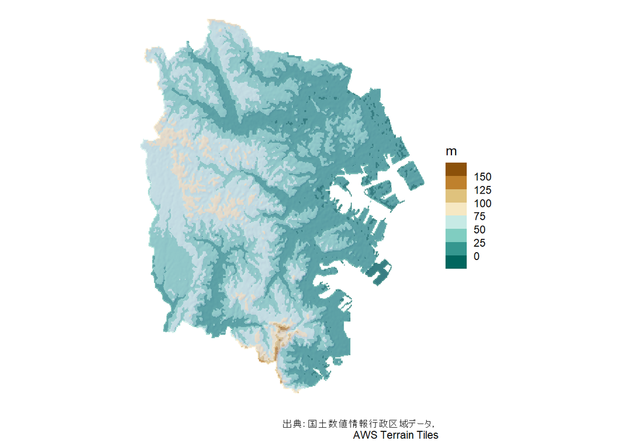

# 7 参考ウェブサイト

- [Hillshade effects](https://dominicroye.github.io/en/2022/hillshade-effects/)

**RによるGISデータの可視化**

- チュートリアル[ホーム](https://shinichiro-iwata.github.io/geospatial-data-visualization/)

**アイコン**

Font Awesome 6.7.2

[^1]: [標高・傾斜度メッシュデータの可視化](https://shinichiro-iwata.github.io/geospatial-data-visualization/elevation-slope-visualization.html)では[国土数値情報標高・傾斜度メッシュデータ](https://nlftp.mlit.go.jp/ksj/gml/datalist/KsjTmplt-G04-d.html)を用いて標高を可視化．このメッシュデータは[基盤地図情報数値標高モデル](https://fgd.gsi.go.jp/download/ref_dem.html)のラスターデータをシェープファイル（ベクターデータ：ポイント，ライン，ポリゴンで表現されるデータ形式）に変換されている．
[^2]: Natural Earthの利用方法の詳細は[Natural Earthの地理空間データの可視化](https://shinichiro-iwata.github.io/geospatial-data-visualization/rnaturalearth-visualization.html)参照．